# Sampling and Summarizing Data

## Notes to self:

- students that decided to use R for repeated random samples in PS2 had a problem where the random samples were different when they knit to Word. We could teach `set.seed()` or how to put R code inline.

## Plan for today

- Basic summary statistics
- Reading in data with `read.csv()`
- Summarizing data with the `dplyr` package
- Sampling with `sample()` and `sample_n()`
- Making more cool plots with `ggplot2`

## Basic summary statistics (review)

```r
class_size <- c(10, 14, 37, 23, 42, 300, 55, 9, 278, 7)
mean(class_size)
```

```
## [1] 77.5
```

```r
round(mean(class_size), digits = 0)
```

```
## [1] 78
```

## Basic summary statistics (new)

```r
median(class_size) #median
```

```
## [1] 30
```

```r
max(class_size) #maximum
```

```
## [1] 300
```

```r
min(class_size) #minimum
```

```
## [1] 7
```

```r
max(class_size) - min(class_size) #range
```

```
## [1] 293
```

## Basic summary statistics (new)

```r
var(class_size) #variance
```

```
## [1] 12703.83
```

```r
sd(class_size) #standard deviation
```

```
## [1] 112.7113
```

```r
sd(class_size)^2 #also variance (I promise)
```

```
## [1] 12703.83
```

## But…

## What if you want to summarize a huge data frame into a nice table of results?

## What if you want to calculate summary statistics for separate groups?

## Reading in data

- Export your Excel spreadsheet to .csv
- Put the .csv in same folder as your .Rmd
- Read in data with `read.csv("name.csv")`
- Assign this data frame to a variable
- Give it a short, descriptive name!

## Reading in data

```r
firefly <- read.csv("firefly_weight.csv")
head(firefly)
```

```
##   ID treatment weight  sex
## 1 A1         A 0.0286    L
## 2 A2         A     NA <NA>
## 3 A3         A 0.0613    F
## 4 A4         A 0.0734    L
## 5 A5         A 0.0521    M
## 6 A6         A 0.0872    F
```

## Reading in data

```r
firefly <- na.omit(firefly)
head(firefly)
```

```
##   ID treatment weight sex
## 1 A1         A 0.0286   L
## 3 A3         A 0.0613   F
## 4 A4         A 0.0734   L
## 5 A5         A 0.0521   M
## 6 A6         A 0.0872   F
## 7 A7         A 0.0766   F
```

## Coding hack #1

## Named and unnamed arguments

- So far, we've been using named arguments for all functions:

```r
library(ggplot2)
firefly_plot <- ggplot(data = firefly,
                       aes(x = sex, y = weight))
```

- You don't have to name them (write `data =`) if you insert them into the function in the right order

```r
firefly_plot <- ggplot(firefly, aes(x = sex, y = weight))
```

- To figure out the right order, check the help file

## Summarizing data

- We're going to use the `dplyr` package to summarize data

`summarize(data, new_variable = function(variable))`

```r
library(dplyr)
summarize(firefly, mean_weight = mean(weight))
```

```
##   mean_weight
## 1  0.06414544
```

## Summarizing data

```r
summarize(firefly,
          mean = mean(weight),
          median = median(weight),
          range = max(weight) - min(weight),
          variance = var(weight),
          sd = sd(weight))
```

```
##         mean median  range     variance        sd
## 1 0.06414544 0.0645 0.0694 0.0002643584 0.0162591
```

## Summarizing data by groups

- Sometimes we want summary statistics for groups of data
- Remember the faceted histograms we made last recitation?
- Use `group_by()` to add an *invisible* grouping variable

## Summarizing data by groups

```r
firefly_sex <- group_by(firefly, sex)

summarize(firefly_sex,
          mean = mean(weight),
          median = median(weight),
          range = max(weight) - min(weight),
          variance = var(weight),
          sd = sd(weight))
```

```
## # A tibble: 3 x 6
##   sex     mean median  range variance     sd
##   <fct>  <dbl>  <dbl>  <dbl>    <dbl>  <dbl>
## 1 F     0.0750 0.0759 0.0316 0.000110 0.0105
## 2 L     0.0659 0.0675 0.0694 0.000318 0.0178
## 3 M     0.0545 0.0529 0.0478 0.000149 0.0122
```

## Coding hack #2

## The "pipe" (`%>%`)

- Used in `dplyr` and many other Tidyverse packages
- macOS shortcut: command + shift + m
- Windows shortcut: control + shift + m
- Allows you to "chain" functions together

```r
firefly %>%
  group_by(sex) %>%
  summarize(mean_weight = mean(weight))
```

```
## # A tibble: 3 x 2
##   sex   mean_weight
##   <fct>       <dbl>
## 1 F          0.0750
## 2 L          0.0659
## 3 M          0.0545
```

## The "pipe" (`%>%`)

- Using the pipe makes your code more readable to humans!

```r
firefly %>%
  group_by(sex) %>%
  summarize(mean_weight = mean(weight))
```

```
## # A tibble: 3 x 2
##   sex   mean_weight
##   <fct>       <dbl>
## 1 F          0.0750
## 2 L          0.0659
## 3 M          0.0545
```

"Take the firefly dataset, group it by sex, then summarize it by taking the mean weight for each sex"

## The "pipe" (`%>%`)

- What it actually does is put whatever is on the left into the first argument of the function on the right

```r
firefly %>% group_by(sex)
# is the same as
group_by(firefly, sex)
```

- Only works with functions that have `data` as first argument
- (This is all Tidyverse functions, but not all base R functions)

## Practice

- Make this code more readable using `%>%`

```r
iris_grouped <- group_by(iris, Species)

summarize(iris_grouped,
          mean = mean(Sepal.Length),
          median = median(Sepal.Length),
          range = max(Sepal.Length) - min(Sepal.Length),
          variance = var(Sepal.Length))
```

## Sampling

- Randomly sampling from a vector is quite simple

```r
class_size
```

```
##  [1]  10  14  37  23  42 300  55   9 278   7
```

```r
sample(class_size, size = 3, replace = F)
```

```
## [1]  37  42 278
```

```r
sample(class_size, 3, F)
```

```
## [1] 278   9   7
```

## Sampling

- Randomly sampling rows from a data frame is also easy!

```r
head(firefly)
```

```
##   ID treatment weight sex
## 1 A1         A 0.0286   L
## 3 A3         A 0.0613   F
## 4 A4         A 0.0734   L
## 5 A5         A 0.0521   M
## 6 A6         A 0.0872   F
## 7 A7         A 0.0766   F
```

```r
sample_n(firefly, size = 3, replace = F)
```

```
##     ID treatment  weight sex
## 57 D12         D 0.07553   L
## 26 B11         B 0.06200   L
## 28 B13         B 0.04960   L
```

```r
sample_n(firefly, 3, F)
```

```
##     ID treatment weight sex
## 16  B1         B 0.0567   M
## 25 B10         B 0.0330   M
## 52  D7         D 0.0892   F
```

## Putting it all together

"Take the iris dataset, randomly sample 30 rows, group the data by species, then summarize the sample by taking the mean and standard deviation of petal length for each species…

…and turn your random sample into a boxplot!"

## Putting it all together

```r
iris_sample <- iris %>%
  sample_n(30, F)

iris_summary <- iris_sample %>%
  group_by(Species) %>%
  summarize(petal_length = mean(Petal.Length),
            sd_length = sd(Petal.Length))

iris_summary
```

```
## # A tibble: 3 x 3
##   Species    petal_length sd_length
##   <fct>             <dbl>     <dbl>
## 1 setosa             1.55     0.184
## 2 versicolor         4.23     0.577
## 3 virginica          5.37     0.347
```

## Putting it all together

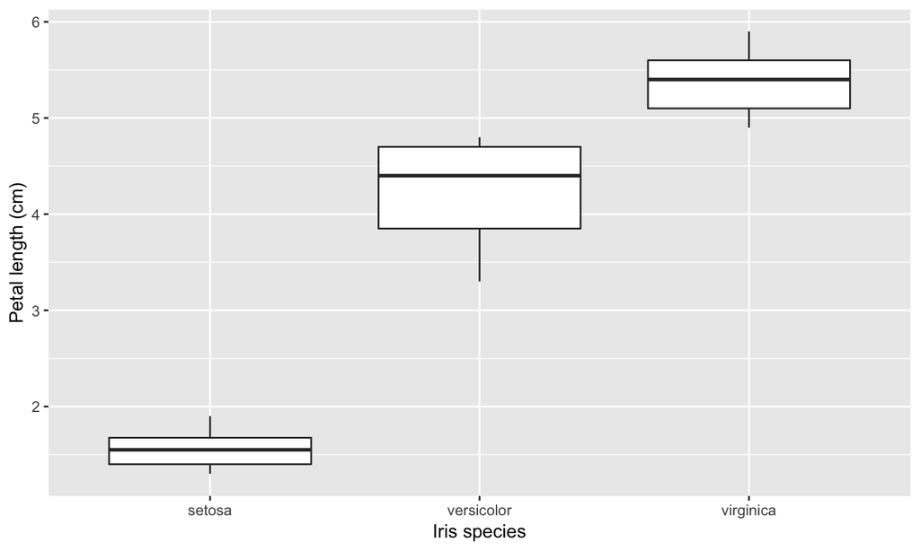

```r
ggplot(iris_sample, aes(x = Species, y = Petal.Length)) +
  geom_boxplot() +
  labs(x = "Iris species", y = "Petal length (cm)")
```

## Making more cool plots

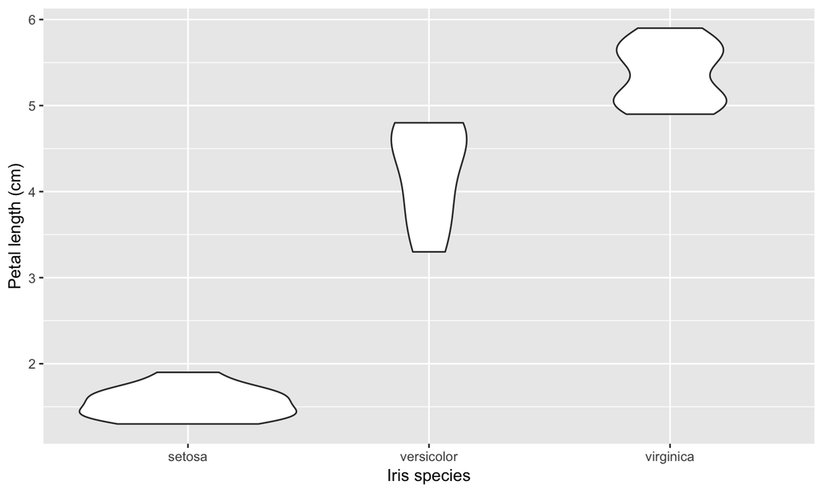

```r
ggplot(iris_sample, aes(x = Species, y = Petal.Length)) +
  geom_violin() +
  labs(x = "Iris species", y = "Petal length (cm)")
```

## Making more cool plots

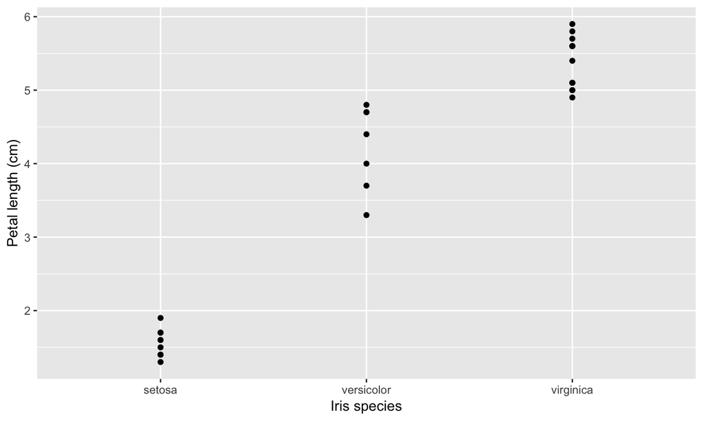

```r
ggplot(iris_sample, aes(x = Species, y = Petal.Length)) +
  geom_point() +
  labs(x = "Iris species", y = "Petal length (cm)")
```

## Making more cool plots

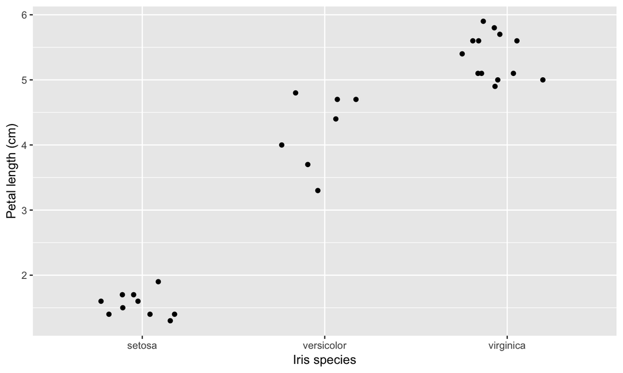

```r
ggplot(iris_sample, aes(x = Species, y = Petal.Length)) +
  geom_jitter(width = 0.25, height = 0) +
  labs(x = "Iris species", y = "Petal length (cm)")
```

## Making more cool plots

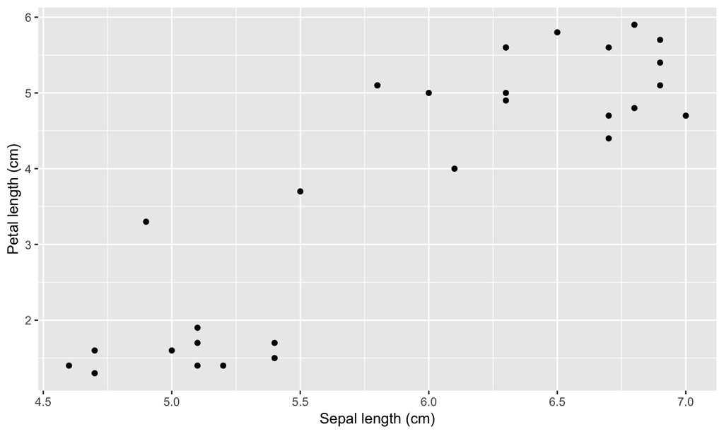

```r
ggplot(iris_sample, aes(x = Sepal.Length, y = Petal.Length)) +
  geom_point() +
  labs(x = "Sepal length (cm)", y = "Petal length (cm)")
```

## Coding hack #3

## Putting your name on your assignment

- What to do with the YAML header?